# Music AD RNASeq

Christine Lucille Kuryla (clk2162)

2023-11-29

## Load and explore the data

First, load the data.

```r
# metadata
metadata_raw <- read.table("./data_edited/music_ad_copyandpaste.txt",
                           col.names =
                             c("gse_number",
                             "group",
                             "timepoint",
                             "subj_id",
                             "sample_id")
                           )
metadata <- metadata_raw %>%
  mutate(group = str_sub(group, 1, -2)) %>%
  mutate(timepoint = str_sub(timepoint, 1, -2)) %>%
  mutate(group = as.factor(group),
         timepoint = as.factor(timepoint)) %>%
  mutate(group = fct_relevel(group, "Control", "ACD")) %>%
  mutate(timepoint = fct_relevel(timepoint, "Timepoint-1", "Timepoint-2"))

# raw count data
countdata_raw <- read_tsv("./internet_files/GSE239282_raw_counts_GRCh38.p13_NCBI.tsv")

countdata <- countdata_raw %>%
  column_to_rownames("GeneID")
```

```r
# Not all of the samples in the metadata file are in the RNASeq countdata file, so we will filter the metadata

# Filter to only have consistent subjects. The subjects are not consistent in the pre and post music groups (timepoint 1 and timepoint 2).

acd_1 <- metadata %>%
  filter(group == "ACD") %>%
  filter(timepoint == "Timepoint-1") %>%
  pull(subj_id)

acd_2 <- metadata %>%
  filter(group == "ACD") %>%
  filter(timepoint == "Timepoint-2") %>%
  pull(subj_id)

control_1 <- metadata %>%
  filter(group == "Control") %>%
  filter(timepoint == "Timepoint-1") %>%
  pull(subj_id)

control_2 <- metadata %>%
  filter(group == "Control") %>%
  filter(timepoint == "Timepoint-2") %>%
  pull(subj_id)

acd_intersect <- intersect(acd_1, acd_2)
control_intersect <- intersect(control_1, control_2)

final_subject_set <- c(acd_intersect, control_intersect)

# filter

metadata_filtered <- metadata %>%
  filter(gse_number %in% colnames(countdata)) %>%
  filter(subj_id %in% final_subject_set)

countdata_filtered <- countdata %>%
  select(all_of(pull(metadata_filtered, gse_number)))

metadata <- metadata_filtered
countdata <- countdata_filtered
```

```r
summary_acd <- metadata %>%
  filter(group == "ACD") %>%
  group_by(timepoint) %>%
  summarize(n_acd = n())

summary_control <- metadata %>%
  filter(group == "Control") %>%
  group_by(timepoint) %>%
  summarize(n_control = n())

inner_join(summary_acd, summary_control, by = "timepoint") %>%
  knitr::kable()
```

| timepoint | n_acd | n_control |
| --- | --- | --- |
| Timepoint-1 | 15 | 12 |
| Timepoint-2 | 12 | 13 |

```r
countdata %>%
  summarise(n_transcripts = n()) %>%
  knitr::kable()
```

| n_transcripts |
| --- |
| 39376 |

There seems to be something that is separating the groups more than condition or timepoint. It is likely a batch effect. I don’t think the rest of this analysis is worthwhile; QC has failed.

## Former Analysis Plan

For our first analysis, we will determine the differential transcript expression between the ACD subjects and the controls at each time point. This will help us see if the two groups (ACD and control) have different gene expression (regardless of the intervention).

Four our second analysis, we will determine the differential transcript expression between Timepoint 2 (after music) and Timepoint 1 (baseline - before music) for both the AD and control subjects. This will show us the difference in their responses to the intervention.

*Analysis 1 – ACD Subjects vs Controls (for each timepoint separately)*

We will begin by loading and exploring the data. First, we will normalize and/or perform a variance stabilized transformation on the counts in order to visualize and explore group separation using PCA, heatmaps, and dendrograms. Then, we will perform a differential expression (DE) analysis for ACD Subjects vs Controls (for each timepoint separately). We will explore which genes are significantly differentially expressed (up or down regulated), visualize with another heatmap and volcano plot, perform gene ontology (GO) analysis, pathway analysis, and GSEA.

*Analysis 2 – After Music vs Before Music (for ACD and controls separately)*

We will perform an analogous analysis, except this time we will explore pre- and post- music separation an differential expression.

*Combined Analysis – Relating and Interpreting Results*

We will look at overlapping differentially expressed genes, compare the various analyses, and interpret the differences.

## Define Functions

```r
dds <- DESeqDataSetFromMatrix(countData = countdata,
                              colData = metadata,
                              design= ~ group)
```

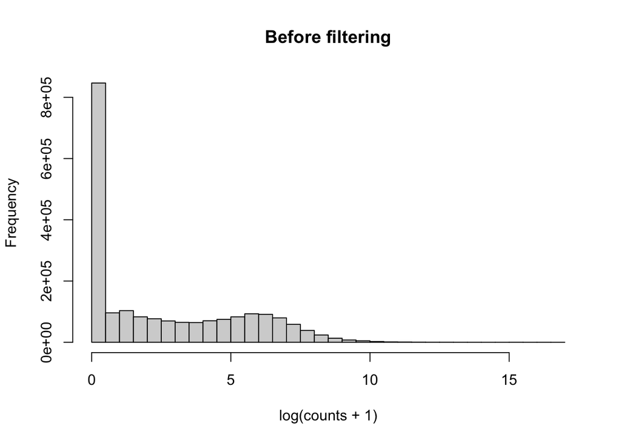

```r
  # Visualize the effect of the filtering
    # Before filtering
    hist(log1p(counts(dds)), main = "Before filtering", xlab = "log(counts + 1)", breaks = 50)
```

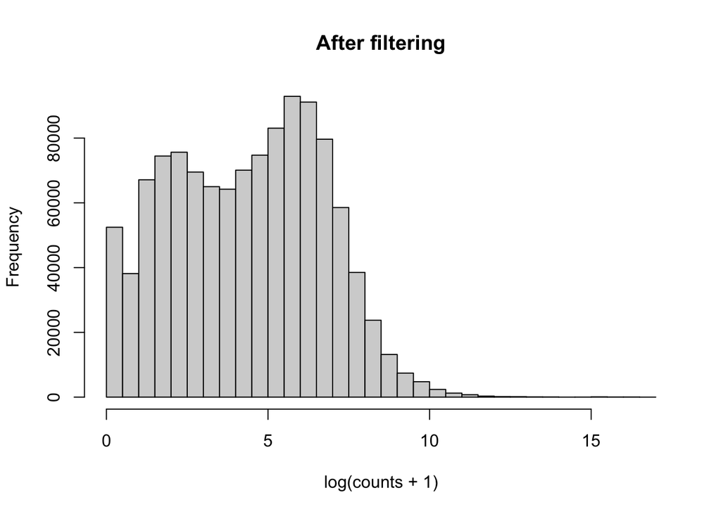

```r
    # After filtering
  #  keep <- rowSums(counts(dds)) >= 10
    keep <- rowSums(assay(dds) >= 5) >= 4
    dds_filtered <- dds[keep,]
    hist(log1p(counts(dds_filtered)), main = "After filtering", xlab = "log(counts + 1)", breaks = 50)
```

```r
    dds <- dds_filtered

  # relevel (not necessary for the unsupervised analysis but good for future object DE analysis)
  # make sure reference is set to the reference level for interpretablity
  relevel(dds$group, ref = "Control")
```

```
##  [1] Control Control Control Control Control Control ACD     ACD     Control
## [10] Control Control Control Control Control ACD     Control Control ACD
## [19] ACD     ACD     ACD     ACD     ACD     ACD     ACD     Control ACD
## [28] ACD     Control Control Control Control Control ACD     ACD     Control
## [37] Control ACD     ACD     Control ACD     ACD     ACD     ACD     Control
## [46] Control ACD     ACD     ACD     ACD     ACD     ACD
## Levels: Control ACD
```

```r
  # Estimate size factors, accounts for library depth and composition (1 and 3)
  # This estimates the size factors and inserts them into the dds object so we can use to normalize
  dds <- estimateSizeFactors(dds)
  sizeFactors(dds)
```

```
## GSM7662531 GSM7662532 GSM7662533 GSM7662534 GSM7662535 GSM7662536 GSM7662537
##  1.0292922  1.0886152  0.7806924  0.7449890  1.3188120  1.4647051  0.9875262
## GSM7662538 GSM7662539 GSM7662540 GSM7662541 GSM7662542 GSM7662543 GSM7662544
##  1.2148407  1.0129374  1.0425282  1.5998835  1.2308788  1.4237882  1.1537675
## GSM7662546 GSM7662547 GSM7662548 GSM7662549 GSM7662550 GSM7662551 GSM7662552
##  1.1413292  1.1117521  1.4606751  1.1426756  1.2163053  1.1786820  1.1084111
## GSM7662553 GSM7662556 GSM7662557 GSM7662558 GSM7662559 GSM7662561 GSM7662562
##  0.7423760  1.2877331  1.0652151  1.0257799  1.3748554  0.4082677  0.6043976
## GSM7662563 GSM7662564 GSM7662565 GSM7662566 GSM7662568 GSM7662569 GSM7662570
##  0.9500219  1.3008153  1.2663800  1.1040514  1.1287925  0.6422418  0.5400604
## GSM7662571 GSM7662572 GSM7662573 GSM7662574 GSM7662576 GSM7662577 GSM7662578
##  1.1607148  0.8056137  1.0124517  0.5781326  0.8219473  1.0886395  1.0309766
## GSM7662579 GSM7662580 GSM7662581 GSM7662582 GSM7662584 GSM7662585 GSM7662586
##  0.8389292  0.8068485  1.3663533  1.3504669  0.7146330  1.3443434  1.2931285
## GSM7662587 GSM7662588 GSM7662590
##  0.7718177  1.0032215  0.6634338
```

```r
dds <- DESeq(dds)
```

```
## -- replacing outliers and refitting for 65 genes
## -- DESeq argument 'minReplicatesForReplace' = 7
## -- original counts are preserved in counts(dds)
```

```r
resultsNames(dds) # lists the coefficients
```

```
## [1] "Intercept"            "group_ACD_vs_Control"
```

```r
res <- results(dds, name="group_ACD_vs_Control")
# or to shrink log fold changes association with condition:
res <- lfcShrink(dds, coef="group_ACD_vs_Control", type="apeglm")
```

```
## using 'apeglm' for LFC shrinkage. If used in published research, please cite:
##     Zhu, A., Ibrahim, J.G., Love, M.I. (2018) Heavy-tailed prior distributions for
##     sequence count data: removing the noise and preserving large differences.
##     Bioinformatics. https://doi.org/10.1093/bioinformatics/bty895
```

```
## using ntop=500 top features by variance
```

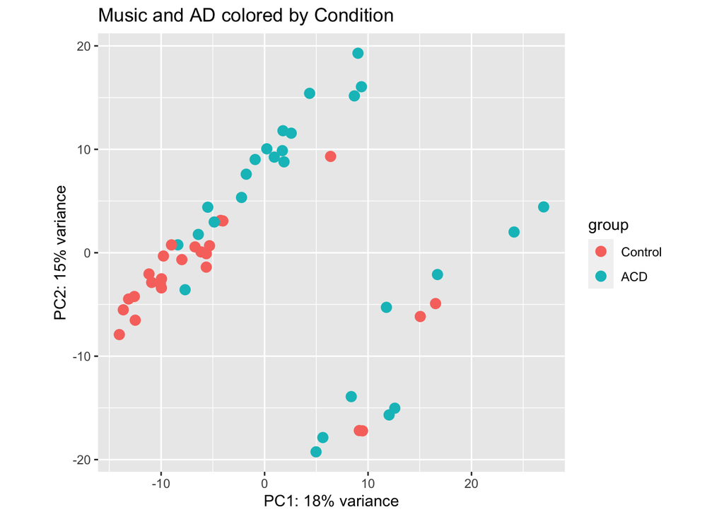

```r
vsd <- vst(dds, blind=TRUE)
plotPCA(vsd, intgroup="group") +
  ggtitle("Music and AD colored by Condition")
```

```
## using ntop=500 top features by variance
```

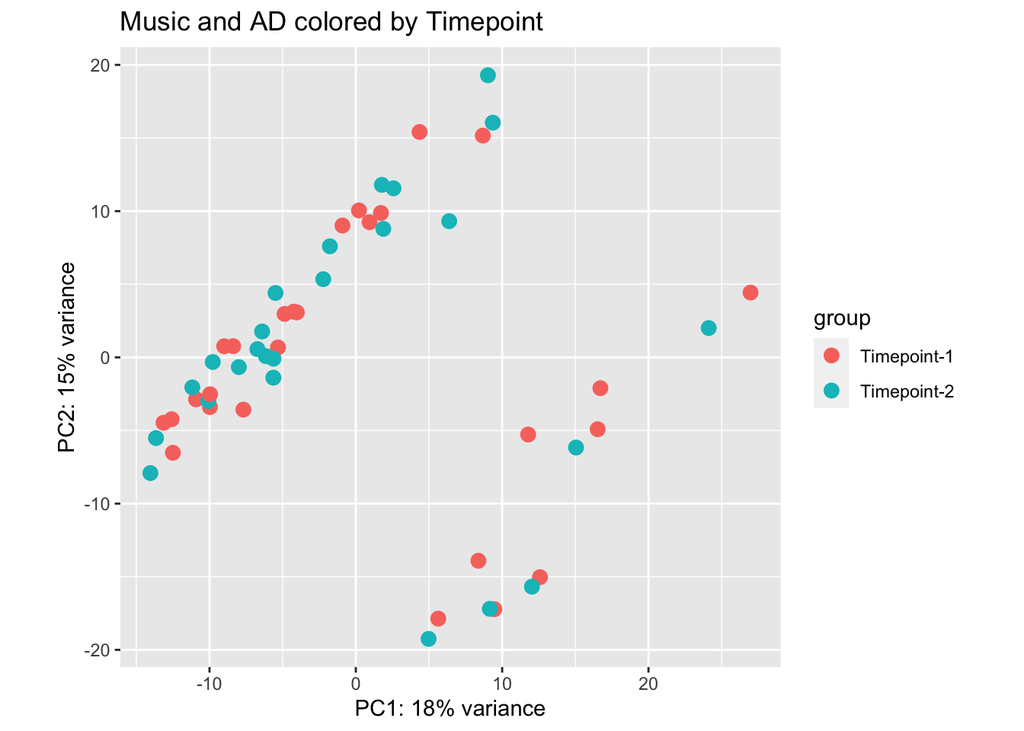

```r
plotPCA(vsd, intgroup="timepoint") +
  ggtitle("Music and AD colored by Timepoint")
```

```
## using ntop=500 top features by variance
```

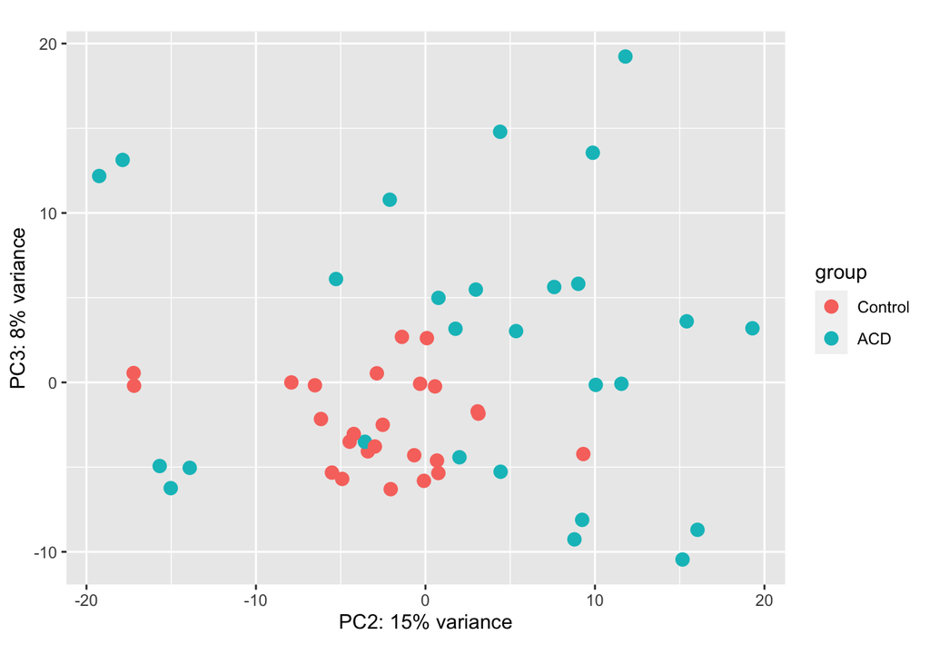

```r
plotPCA(vsd, intgroup="group", pcsToUse = 2:3)
```

```
## using ntop=500 top features by variance
```

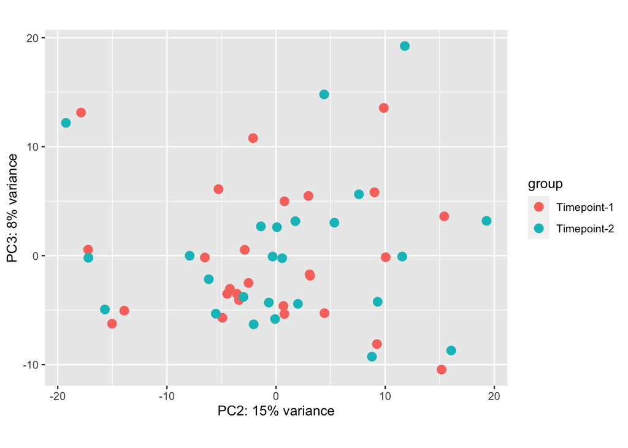

```r
plotPCA(vsd, intgroup="timepoint", pcsToUse = 2:3)
```

## Analysis 2 - comparing before and after music